# Lecture #6: The Derivative at a Point & Interpretations

MATH 145 – Calculus I

Torin Quinlivan

tquinlivan@knox.edu

Knox College

September 9, 2025

## Instantaneous Rate of Change

Recall that if we want to find the instantaneous rate of change at a point $x = a$, we use the following definition:

For a function $f$, the instantaneous rate of change of $f$ at point $x = a$ is the quantity

$$IV_{t=a} = \lim\limits_{h \to 0} AV_{[a,a+h]} = \lim\limits_{h \to 0} \frac{f(a + h) - f(a)} {h}.$$

## The Derivative at a Point

Using this definition, we can define the derivative of a function $f$ with respect to $x$ evaluated at $x=a$:

Let $f$ be a function and $x = a$ a value in the function’s domain. We define the derivative of $f$ with respect to $x$ evaluated at $x = a$, denoted $f'(a)$, by the formula

$$f'(a) = \lim\limits_{h \to 0} \frac{f(a + h) - f(a)} {h}.$$

provided this limit exists.

## Example: The Derivative at a Point

Let $f(x) = 3x - 4$.

1. Find $f'(2)$.
2. Find $f'(-1)$.
3. Find $f'(0)$.

## Example: The Derivative at a Point

Let $g(x) = x^2 + 2$.

1. Find $g'(4)$.
2. Find $g'(-2)$.
3. Find $g'(0)$.

## Example: The Derivative at a Point

Let $h(x) = \dfrac{1}{x}$.

1. Find $h'(6)$.
2. Find $h'(-3)$.
3. Find $h'(0)$.

## Interpretations of the Derivative at a Point

There are a few different interpretations of the derivative of $f$ with respect to $x$ at $x = a$. (This is not an exhaustive list.)

- $f'(a)$ is the *instantaneous rate of change* of $f(x)$ at $x = a$.
- $f'(a)$ is the *instantaneous velocity* of $f(t)$ at $x = a$ if $f(t)$ represents a position.
- $f'(a)$ is also the *slope of the tangent line* to $f(x)$ at the point $(a, f(a))$.

## Example: The Slope of the Tangent Line

Let $g(x) = x^2 + 2$.
$$\begin{aligned}
AV_{[1,5]}\, g(x) &= 6 \\
AV_{[1,3]}\, g(x) &= 4 \\
AV_{[1,2]}\, g(x) &= 3 \\
AV_{[1,1.5]}\, g(x) &= 2.5 \\
AV_{[1,1.25]}\, g(x) &= 2.25 \\
AV_{[1,1.1]}\, g(x) &= 2.1 \\
AV_{[1,1.01]}\, g(x) &= 2.01 \\
AV_{[1,1.001]}\, g(x) &= 2.001 \\
&\vdots \\
g'(1) &= 2
\end{aligned}$$

## Example: The Slope of the Tangent Line

Let’s try that from the other direction.
$$\begin{aligned}
AV_{[-3,1]}\, g(x) &= -2 \\
AV_{[-1,1]}\, g(x) &= 0 \\
AV_{[0,1]}\, g(x) &= 1 \\
AV_{[0.5,1]}\, g(x) &= 1.5 \\
AV_{[0.75,1]}\, g(x) &= 1.75 \\
AV_{[0.9,1}\, g(x) &= 1.9 \\
AV_{[0.99,1]}\, g(x) &= 1.99 \\
AV_{[0.999,1]}\, g(x) &= 1.999 \\
&\vdots \\
g'(1) &= 2
\end{aligned}$$

## The Slope of the Tangent Line

There is an applet that shows the way that the limit of the slope of the secant line approaches the slope of the tangent line.

https://www.desmos.com/calculator/ndruflgw8x

## Example: The Derivative, Graphically

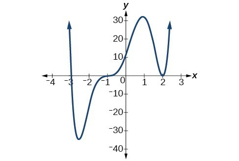

What are some points on this graph where the derivative is negative?

What are some points on this graph where the derivative is positive?

What are some points on this graph where the derivative is zero?

## Example: The Derivative, Table

A potato is placed in an oven, and the potato’s temperature $F$ (in degrees Fahrenheit) at various points in time $t$ is taken and recorded in the following table. Time $t$ is measured in minutes.

| $t$ | 0 | 15 | 30 | 45 | 60 | 75 | 90 |
| --- | --- | --- | --- | --- | --- | --- | --- |
| $F(t)$ | 70 | 180.5 | 251 | 296 | 324.5 | 342.8 | 354.5 |

If $F(t)$ is the temperature at time $t$, estimate the instantaneous rate of change of the temperature at $t = 45$.

## The Central Difference Approximation

The central difference approximation to the value of the derivative at $x = a$ is given by

$$f'(a) \approx \frac{f(a + h) - f(a - h)}{2h}.$$

This quantity measures the slope of the secant line to $y = f(x)$ through the points $(a-h, f(a-h))$ and $(a+h, f(a+h))$.

## Example: The Derivative, Table

A potato is placed in an oven, and the potato’s temperature $F$ (in degrees Fahrenheit) at various points in time $t$ is taken and recorded in the following table. Time $t$ is measured in minutes.

| $t$ | 0 | 15 | 30 | 45 | 60 | 75 | 90 |
| --- | --- | --- | --- | --- | --- | --- | --- |
| $F(t)$ | 70 | 180.5 | 251 | 296 | 324.5 | 342.8 | 354.5 |

If $F(t)$ is the temperature at time $t$, estimate $F'(45)$.

## Example: Derivatives and Units

The temperature change $T$ (in Farhenheit degrees), in a patient, that is generated by a dose $q$ (in milliliters) of a drug is given by the function $T = f(q)$.

1. What does it mean to say $f(50) = 0.75$? Answer in a complete sentence, using correct units.
2. A person’s sensitivity, $s$, to the drug is defined by the function $s(q) = f'(q)$. What are the units of sensitivity?
3. Suppose the $f'(50) = -0.02$. Write a complete sentence to explain the meaning of this value. Include in your response the information $f(50) = 0.75$.

## Derivatives and Units

$$f'(a) = \lim\limits_{h \to 0} \frac{f(a + h) - f(a)} {(x + h) - x}.$$

The units of the derivative of a function $f$ with respect to $x$ evaluated at $x=a$, where $y = f(x)$, are $\dfrac{\textrm{units of }y}{\textrm{units of }x}$.